# Exercise: Dipper Model with Gender and Time

### Dipper CJS model with gender and time dependence

Now, you’ll modify the dipper CJS model to use the `gender` variable. Modify your model, so that:

1. Probability of detection depends on gender. That is, `gender = 1` individuals have probability of detection $p_1$, and `gender = 2` individuals have probability of detection $p_2$.
2. Survival probability is different for each year. That is, the probability of surviving from year 1 to year 2 is $\phi_1$, and the probability of surviving from year 2 to year 3 is $\phi_2$, etc. So your final model will have parameters $\phi_1$, $\phi_2$, $\phi_3$, $\phi_4$, $\phi_5$, and $\phi_6$, representing the survival probabilities from each year.

### Results

See if you can get the same (or similar) results for the modified dipper model:

```r
round(samplesSummary(samples2), 2)
```

```
##        Mean Median St.Dev. 95%CI_low 95%CI_upp
## p[1]   0.91   0.91    0.04      0.82      0.96
## p[2]   0.87   0.87    0.04      0.77      0.94
## phi[1] 0.62   0.63    0.11      0.41      0.83
## phi[2] 0.46   0.46    0.07      0.34      0.60
## phi[3] 0.48   0.48    0.06      0.37      0.60
## phi[4] 0.62   0.62    0.06      0.51      0.73
## phi[5] 0.61   0.61    0.05      0.49      0.71
## phi[6] 0.62   0.62    0.07      0.47      0.77
```

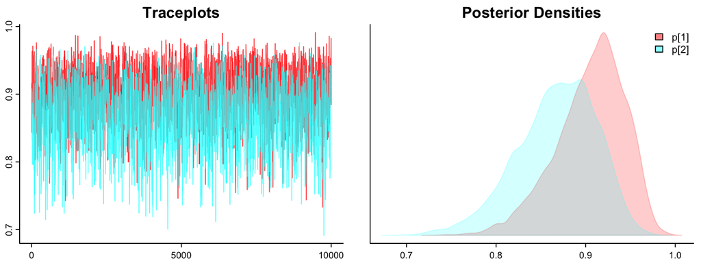

```r
library(basicMCMCplots)

basicMCMCplots::samplesPlot(samples2, 'p')
```

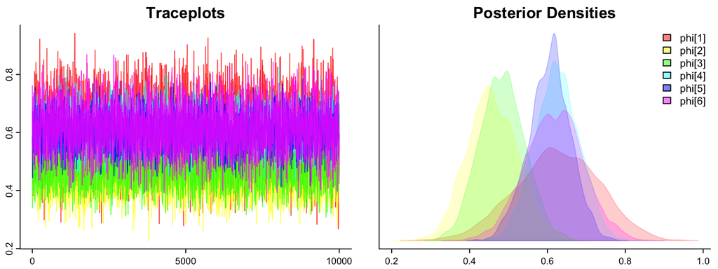

```r
basicMCMCplots::samplesPlot(samples2, 'phi')
```

### WAIC for model comparison

If you have time, try using the WAIC model information criterion, to compare these two versions of the dipper model.

NIMBLE’s MCMC will calculate WAIC for you. You can do this by supplying the argument `WAIC = TRUE` to `runMCMC`. You’ll also have to provide the argument `enableWAIC = TRUE` to `configureMCMC`, and also monitor all latent states in the model (in this case, the `x`’s).